# 6a

Yiqiao Yin

2/17/2021

## Model Fitting and Expansion

Assignment: With your partner, fit a model to your data and then do some model checking. Use the results of the model check to inspire some model expansion. Fit two new models and check their fits too.

This assignment I did it myself and there is no collaboration. I am taking what we learned from homework *3a* and apply the approach on a real data (with 2 covariates). The goal is to see if we can generate a good fit from direct approach and use that as benchmark. If the fit is bad (which I guess it will be), then the idea is to expand and play around with parameters or model to see if we can generate a better fit.

### Recall Assignment 3a

```r
library(cmdstanr)
path = "C:/Users/eagle/OneDrive/Course/CU Stats/STATS GR6102 - Applied Statistics II/InClass/stan/"
file <- file.path(path, "linearModel_6a.stan")
mod <- cmdstan_model(file)
```

```
## Model executable is up to date!
```

```r
mod$print()
```

```
## data {
##   int N;
##   vector[N] x;
##   vector[N] y;
## }
## parameters {
##   real<lower=0> a;
##   real<lower=0> b;
##   real<lower=0> sigma;
## }
## model {
##   y ~ normal(1 ./ (a + b*x), sigma);
## }
```

```r
x = runif(100, 0, 10)
alpha = 2
beta = 3
error = 0.02
fakeY  = 1/(alpha + beta*x) + error
```

```r
# names correspond to the data block in the Stan program
data_list <- list(N = 100, x = x, y = fakeY)
init <- function() {
  list(a = runif(1, 0, 10),
       b = runif(1, 0, 10),
       sigma = runif(1, 0, 1)) }

fit <- mod$sample(
  data = data_list,
  seed = 123,
  chains = 4,
  parallel_chains = 4,
  save_warmup = TRUE,
  refresh = 0 )
```

```
## Running MCMC with 4 parallel chains...
```

[output not shown]

[output not shown]

[output not shown]

[output not shown]

```
## Chain 1
```

[output not shown]

[output not shown]

[output not shown]

[output not shown]

```
## Chain 2
```

[output not shown]

[output not shown]

[output not shown]

[output not shown]

```
## Chain 3
```

[output not shown]

[output not shown]

[output not shown]

[output not shown]

```
## Chain 4
```

```
## Chain 1 finished in 0.1 seconds.
## Chain 2 finished in 0.1 seconds.
## Chain 3 finished in 0.1 seconds.
## Chain 4 finished in 0.1 seconds.
##
## All 4 chains finished successfully.
## Mean chain execution time: 0.1 seconds.
## Total execution time: 0.2 seconds.
```

```r
# check out the summary of the fit
fit$summary()
```

```
## # A tibble: 4 x 10
##   variable    mean  median      sd     mad      q5     q95  rhat ess_bulk
##   <chr>      <dbl>   <dbl>   <dbl>   <dbl>   <dbl>   <dbl> <dbl>    <dbl>
## 1 lp__     4.39e+2 4.39e+2 1.25e+0 9.96e-1 4.37e+2 4.40e+2  1.00    1794.
## 2 a        2.10e+0 2.10e+0 3.31e-2 3.26e-2 2.05e+0 2.16e+0  1.00    1938.
## 3 b        2.22e+0 2.22e+0 2.89e-2 2.84e-2 2.18e+0 2.27e+0  1.00    2017.
## 4 sigma    7.30e-3 7.26e-3 5.29e-4 5.38e-4 6.49e-3 8.18e-3  1.00    2358.
## # ... with 1 more variable: ess_tail <dbl>
```

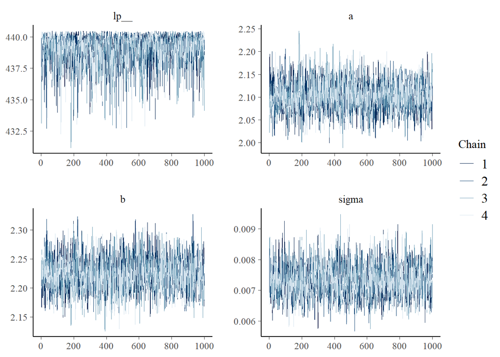

```r
library(bayesplot)
fit$draws() %>% mcmc_trace()
```

### Real Data

This part let me fit what we have in assignment 3a directly on a real world data called *anorexia*.

```r
anorexia = MASS::anorexia
data.table::data.table(anorexia)
```

```
##     Treat Prewt Postwt
##  1:  Cont  80.7   80.2
##  2:  Cont  89.4   80.1
##  3:  Cont  91.8   86.4
##  4:  Cont  74.0   86.3
##  5:  Cont  78.1   76.1
##  6:  Cont  88.3   78.1
##  7:  Cont  87.3   75.1
##  8:  Cont  75.1   86.7
##  9:  Cont  80.6   73.5
## 10:  Cont  78.4   84.6
## 11:  Cont  77.6   77.4
## 12:  Cont  88.7   79.5
## 13:  Cont  81.3   89.6
## 14:  Cont  78.1   81.4
```

[output cut: 59 more lines]

```r
anorexia$Treat = as.numeric(as.factor(as.character(as.factor(anorexia$Treat))))
data.table::data.table(anorexia)
```

```
##     Treat Prewt Postwt
##  1:     2  80.7   80.2
##  2:     2  89.4   80.1
##  3:     2  91.8   86.4
##  4:     2  74.0   86.3
##  5:     2  78.1   76.1
##  6:     2  88.3   78.1
##  7:     2  87.3   75.1
##  8:     2  75.1   86.7
##  9:     2  80.6   73.5
## 10:     2  78.4   84.6
## 11:     2  77.6   77.4
## 12:     2  88.7   79.5
## 13:     2  81.3   89.6
## 14:     2  78.1   81.4
```

[output cut: 59 more lines]

```r
library(cmdstanr)
path = "C:/Users/eagle/OneDrive/Course/CU Stats/STATS GR6102 - Applied Statistics II/InClass/stan/"
file <- file.path(path, "linearModel_6a_apply.stan")
mod <- cmdstan_model(file)
```

```
## Model executable is up to date!
```

```r
mod$print()
```

```
## data {
##   int N;
##   vector[N] x1;
##   vector[N] x2;
##   vector[N] y;
## }
## parameters {
##   real<lower=0> alpha;
##   real<lower=0> beta1;
##   real<lower=0> beta2;
##   real<lower=0> sigma;
## }
## model {
##   y ~ normal(alpha + beta1*x1 + beta2*x2, sigma);
## }
```

```r
n = nrow(anorexia)
x1 = anorexia$Prewt
x2 = anorexia$Treat
y = anorexia$Postwt

# names correspond to the data block in the Stan program
data_list <- list(N = n, x1 = x1, x2 = x2, y = y)
init <- function() {
  list(alpha = rnorm(1, 0, 1),
       beta1 = rnorm(1, 0, 1),
       beta2 = rnorm(1, 0, 1),
       sigma = rnorm(1, 0, 1)) }

fit <- mod$sample(
  data = data_list,
  seed = 123,
  chains = 4,
  parallel_chains = 4,
  save_warmup = TRUE,
  refresh = 0 )
```

```
## Running MCMC with 4 parallel chains...
```

[output not shown]

[output not shown]

[output not shown]

[output not shown]

```
## Chain 1
```

[output not shown]

[output not shown]

[output not shown]

[output not shown]

```
## Chain 1
```

[output not shown]

[output not shown]

[output not shown]

[output not shown]

```
## Chain 3
```

[output not shown]

[output not shown]

[output not shown]

[output not shown]

```
## Chain 3
```

[output not shown]

[output not shown]

[output not shown]

[output not shown]

```
## Chain 3
```

[output not shown]

[output not shown]

[output not shown]

[output not shown]

```
## Chain 3
```

[output not shown]

[output not shown]

[output not shown]

[output not shown]

```
## Chain 4
```

[output not shown]

[output not shown]

[output not shown]

[output not shown]

```
## Chain 4
```

[output not shown]

[output not shown]

[output not shown]

[output not shown]

```
## Chain 4
```

[output not shown]

[output not shown]

[output not shown]

[output not shown]

```
## Chain 4
```

[output not shown]

[output not shown]

[output not shown]

[output not shown]

```
## Chain 4
```

[output not shown]

[output not shown]

[output not shown]

[output not shown]

```
## Chain 4
```

```
## Chain 1 finished in 0.6 seconds.
## Chain 2 finished in 0.6 seconds.
## Chain 3 finished in 0.7 seconds.
## Chain 4 finished in 0.7 seconds.
##
## All 4 chains finished successfully.
## Mean chain execution time: 0.6 seconds.
## Total execution time: 0.7 seconds.
```

```r
# check out the summary of the fit
fit$summary()
```

```
## # A tibble: 5 x 10
##   variable     mean   median     sd    mad       q5      q95  rhat ess_bulk
##   <chr>       <dbl>    <dbl>  <dbl>  <dbl>    <dbl>    <dbl> <dbl>    <dbl>
## 1 lp__     -177.    -177.     1.59   1.45  -180.    -175.     1.00     881.
## 2 alpha      39.8     39.8   13.9   14.1     16.6     63.0    1.00    1144.
## 3 beta1       0.510    0.510  0.168  0.172    0.236    0.790  1.00    1142.
## 4 beta2       1.84     1.78   1.01   1.05     0.290    3.65   1.00    1058.
## 5 sigma       7.72     7.65   0.686  0.667    6.70     8.93   1.00    1752.
## # ... with 1 more variable: ess_tail <dbl>
```

We can also check the summary which is printed above. We can see the sampling average for the posterior distribution for the parameters $\alpha$, $\beta_1$, and $\beta_2$. We can also do a traceplot below.

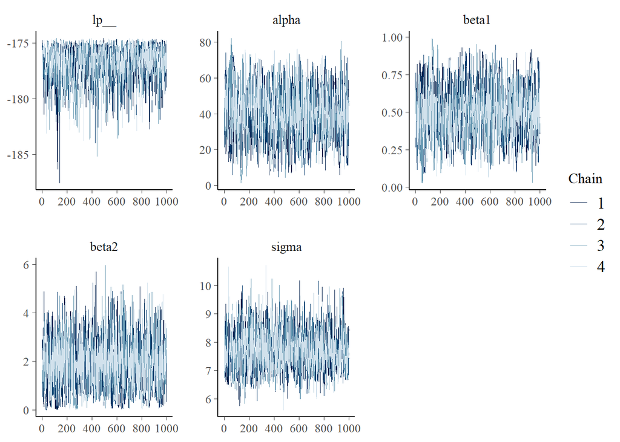

```r
library(bayesplot)
fit$draws() %>% mcmc_trace()
```

### Update

We fit the model using *rstanarm*. Instead of building MCMC using model from $\mathcal{N}(\alpha + \beta_1 X_1 + \beta_2 X_2, \sigma^2)$, we assume Gaussian family using GLM.

```r
fit_rstanarm <- stan_glm(
  Postwt ~ .,
  data = anorexia,
  family = "gaussian" )
```

Check out the summary of the fit.

```r
summary(fit_rstanarm)
```

```
##
## Model Info:
##  function:     stan_glm
##  family:       gaussian [identity]
##  formula:      Postwt ~ .
##  algorithm:    sampling
##  sample:       4000 (posterior sample size)
##  priors:       see help('prior_summary')
##  observations: 72
##  predictors:   3
##
## Estimates:
##               mean   sd   10%   50%   90%
## (Intercept) 40.4   14.6 21.4  40.6  58.9
## Treat        1.7    1.2  0.2   1.7   3.2
## Prewt        0.5    0.2  0.3   0.5   0.7
## sigma        7.6    0.6  6.9   7.6   8.5
##
## Fit Diagnostics:
##            mean   sd   10%   50%   90%
## mean_PPD 85.1    1.3 83.5  85.2  86.8
##
## The mean_ppd is the sample average posterior predictive distribution of the outcome variable (for details see help('summary.stanreg')).
##
## MCMC diagnostics
##               mcse Rhat n_eff
## (Intercept)   0.2  1.0  4859
## Treat         0.0  1.0  4362
## Prewt         0.0  1.0  4931
## sigma         0.0  1.0  4275
## mean_PPD      0.0  1.0  4022
## log-posterior 0.0  1.0  1761
##
## For each parameter, mcse is Monte Carlo standard error, n_eff is a crude measure of effective sample size, and Rhat is the potential scale reduction factor on split chains (at convergence Rhat=1).
```

When fitting a model using MCMC, it is important to check if the chains have converged.

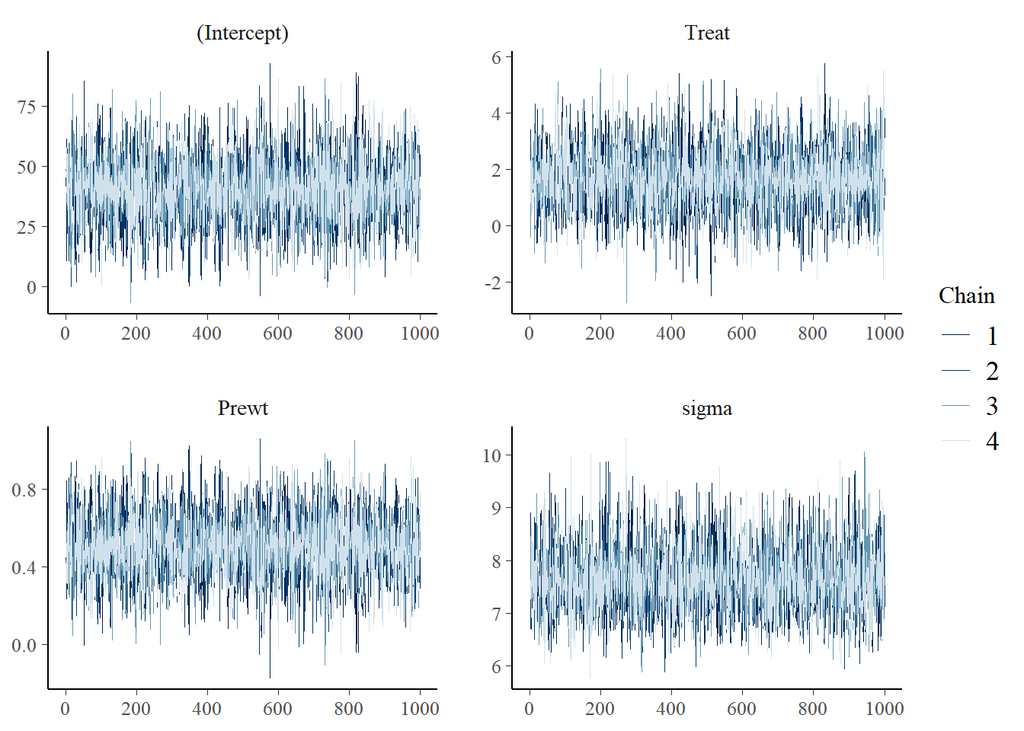

```r
library(bayesplot)

fit_rstanarm %>%
  mcmc_trace()
```

### Model Expansion

It is not entirely sure that a simple linear model can take care of the problem. Let us expand the model by introducing interaction term and also some power terms by the original variables. In other words, let us introduce *Treat_Prewt* that is the product of *Treat* and *Prewt*. We can also introduce *Treat2* and *Prewt2* that are the square of *Treat* and *Prewt*.

```r
anorexia$Treat_Prewt = anorexia$Treat * anorexia$Prewt
anorexia$Treat2 = anorexia$Treat^2
anorexia$Prewt2 = anorexia$Prewt^2
data.table::data.table(anorexia)
```

```
##     Treat Prewt Postwt Treat_Prewt Treat2  Prewt2
##  1:     2  80.7   80.2       161.4      4 6512.49
##  2:     2  89.4   80.1       178.8      4 7992.36
##  3:     2  91.8   86.4       183.6      4 8427.24
##  4:     2  74.0   86.3       148.0      4 5476.00
##  5:     2  78.1   76.1       156.2      4 6099.61
##  6:     2  88.3   78.1       176.6      4 7796.89
##  7:     2  87.3   75.1       174.6      4 7621.29
##  8:     2  75.1   86.7       150.2      4 5640.01
##  9:     2  80.6   73.5       161.2      4 6496.36
## 10:     2  78.4   84.6       156.8      4 6146.56
## 11:     2  77.6   77.4       155.2      4 6021.76
## 12:     2  88.7   79.5       177.4      4 7867.69
## 13:     2  81.3   89.6       162.6      4 6609.69
## 14:     2  78.1   81.4       156.2      4 6099.61
```

[output cut: 59 more lines]

```r
fit_rstanarm <- stan_glm(
  Postwt ~ .,
  data = anorexia,
  family = "gaussian" )
```

Check out the summary of the fit.

```r
summary(fit_rstanarm)
```

```
##
## Model Info:
##  function:     stan_glm
##  family:       gaussian [identity]
##  formula:      Postwt ~ .
##  algorithm:    sampling
##  sample:       4000 (posterior sample size)
##  priors:       see help('prior_summary')
##  observations: 72
##  predictors:   6
##
## Estimates:
##               mean   sd    10%   50%   90%
## (Intercept) 239.9   94.6 117.1 239.6 361.5
## Treat       -11.9   12.8 -27.9 -12.3   5.0
## Prewt        -4.1    2.2  -6.9  -4.1  -1.1
## Treat_Prewt  -0.1    0.1  -0.3  -0.1   0.1
## Treat2        6.0    1.6   4.0   6.0   8.0
## Prewt2        0.0    0.0   0.0   0.0   0.0
## sigma         6.7    0.6   6.0   6.7   7.5
##
## Fit Diagnostics:
##            mean   sd   10%   50%   90%
## mean_PPD 85.2    1.1 83.8  85.2  86.6
##
## The mean_ppd is the sample average posterior predictive distribution of the outcome variable (for details see help('summary.stanreg')).
##
## MCMC diagnostics
##               mcse Rhat n_eff
## (Intercept)   1.9  1.0  2478
## Treat         0.2  1.0  2705
## Prewt         0.0  1.0  2501
## Treat_Prewt   0.0  1.0  2837
## Treat2        0.0  1.0  3525
## Prewt2        0.0  1.0  2508
## sigma         0.0  1.0  3403
## mean_PPD      0.0  1.0  3932
## log-posterior 0.1  1.0  1411
##
## For each parameter, mcse is Monte Carlo standard error, n_eff is a crude measure of effective sample size, and Rhat is the potential scale reduction factor on split chains (at convergence Rhat=1).
```

When fitting a model using MCMC, it is important to check if the chains have converged.

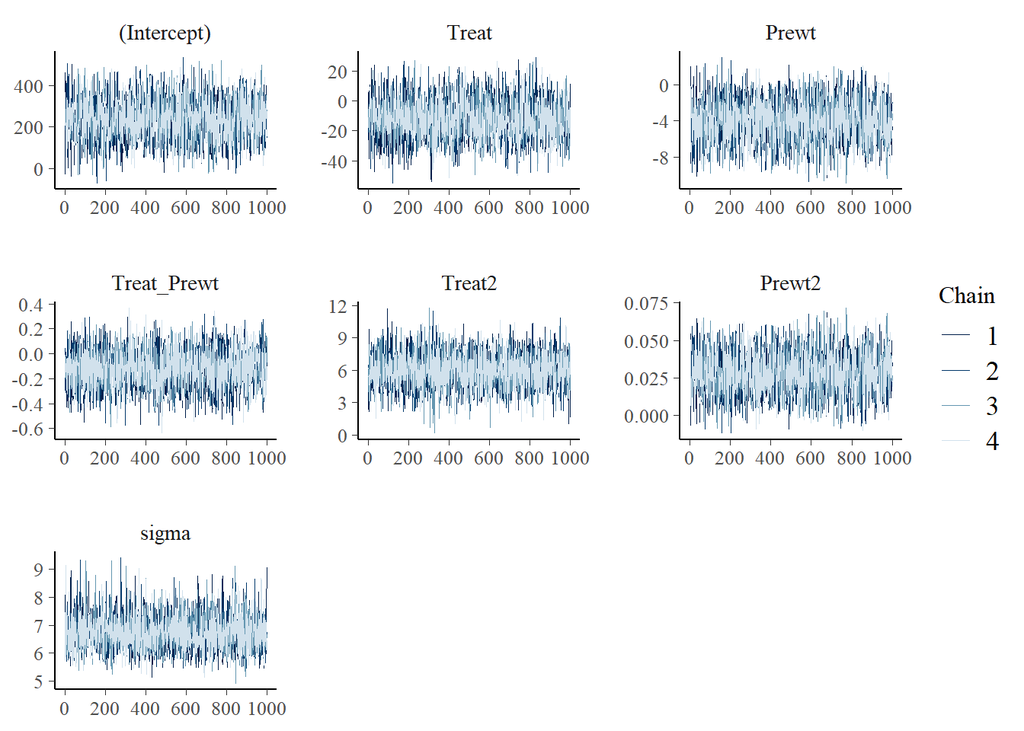

```r
library(bayesplot)

fit_rstanarm %>%
  mcmc_trace()
```

### Bayesian Network

To fulfill my curiosity, let me throw Bayesian Network to this data and see how things go.

First, let us take a quick look of the structure sought by conditional dependency between variables. What’s interesting is *Treat* directly links to the interaction term but *Prewt*, the other interaction term component, is actually linked to *Prewt2* first before it goes to the interaction term.

```r
library(bnlearn)
```

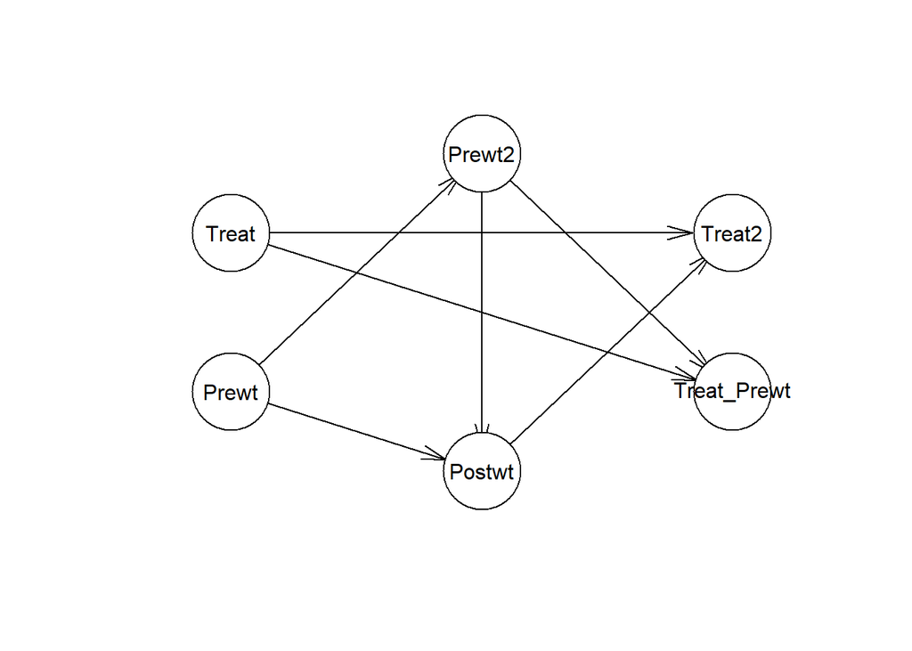

```r
anorexia = data.frame(anorexia)
plot(hc(anorexia))
```

Next, we can immediately find out conditional probability tables (CPT) at each node. For example, say I am interested in *Postwt*, which I can use *bn.fit* to run a quick EM algorithm to learn CPT for this variable.

```r
fittedBN = bn.fit(hc(anorexia), data = anorexia,
                  keep.fitted = TRUE,)
print(fittedBN$Postwt)
```

```
##
##   Parameters of node Postwt (Gaussian distribution)
##
## Conditional density: Postwt | Prewt + Prewt2
## Coefficients:
##  (Intercept)         Prewt        Prewt2
## 485.49608635  -10.28938479    0.06565448
## Standard deviation of the residuals: 7.284123
```